# PREDICTIVE MODELING — D208

## TASK 2: LOGISTIC REGRESSION FOR PREDICTIVE MODELING

## **Part I: Research Question**

**A1: RESEARCH QUESTION:**

What predictor variables are the major contributors for a customer to likely churn?

**A2: OBJECTIVES AND GOALS:**

The objective of predictive modeling is to implement a statistical technique using historical data to create, process, and validate a model to predict future results (Frankenfield, 2021).

In the business world, such as subscription-based businesses like telecommunication, internet, and TV channels providers, a constant battle exists to satisfy customers and prevent them from churning. A churn is when a customer stops or cancels a subscription (Gold & Tzuo, 2020).

The goals are to prevent customers from abandoning the business and acquire more customers based on the correlated variables. For example, suppose we established that higher-income customers tend to stay with the company longer, the company will then focus on that demographic of customers from not leaving the business because the cost of acquiring new customers outweighs the cost of retaining the existing customers.

The main goal of building the predictive model is to help the company retain the customers who are likely to churn by trying to find what features of services highly correlate with churn and improve those features to make the customers stay with the company.

## **Part II: Method Justification**

B. Describe multiple regression methods by doing the following:

**B1: SUMMARY OF ASSUMPTIONS:**

Summarize the assumptions of a multiple regression model.

The logistic regression model makes the following assumptions about the relationships among the dependent and independent variables(Bobbit, 2020):

- The response variable is of binary type i.e yes or no, male or female, 1 or 0
- There are no correlations among the predictor variables
- There is little or no multicollinearity among the predictor variables
- There are no extreme outliers
- A linear relationship exists between the predictor and the logit of the target variables
- More data is required to build a stable model

  The formula for multiple logistic regression is as follows:

  z = β$_{0}$ + β$_{1}$x$_{1}$ + β$_{2}$x$_{2}$ + ...+ β$_{i}$x$_{i}$ --> linear combination of features

  ###

  p(z) = $\frac{{1}}{1 + e^{-z}}$ --> logistic sigmoid function

Where z = linear combination of features , regression coefficients=β$_{i}$, x$_{i}$ = predictor variables, and p(z) = probability between 0 and 1

**B2: TOOL BENEFITS:**

Python is one of the best tools used in the field of data science. Its large scientific-based libraries make it easy to use when performing data analyses. Python is universally liked for its user-and- beginner-friendliness when learning how to program. It is also open-source, meaning no software to purchase when starting (2022). Regarding data science, its vast libraries such as numpy, pandas, and matplotlib enable data analysts and data scientists to acquire insights from the treasure trove of data buried in the data warehouses of many companies (Rane, 2021). For example, using pandas data can be imported from files csv,Excel,and others. On the other hand, matplotlib can utilized for visizualtion aspect during the exploratory data analysis steps where graphs are plotted to see how data points are distributed. For example, for multiple linear regression, the univariate and bivariate graphs can be plotted using the matplotlib library.

**B3: APPROPRIATE TECHNIQUE:**

1. Explain why logistic regression is an appropriate technique to analyze the research question summarized in Part I.

Since the target variable is binary, logistic regression is the most appropriate technique to be used to answer the research question. The goal of the question is to find out the probability of whether a customer is likely to churn or not. This requires a major deviation from the concept of linear regression where the target variable can be any real number (either positve or negative). When dealing with a binary target, the minimum range is 0 and the maximum 1. This is demonstrated by the logit function above. For logistic regression based problems, a classification method will employed to find the what percentage of demographic of customers belong to which of the two categories: churn or not churn.

In logistic regression, the relationship between the target variable and the β parameters is not linear and because of that the least squares method would not work as in linear regression and therefore a method called maximum likelihood will be employed to estimate the probability of predicting the churn or not churn from the data available (Shmueli et al.,2020).

```python
# Importing all the required libraries
import pandas as pd
import numpy as np
import matplotlib.pyplot as plt
import seaborn as sns
from sklearn.preprocessing import StandardScaler
from sklearn.decomposition import PCA
import statsmodels.api as sm
from scipy import stats
from sklearn.linear_model import LogisticRegression
from sklearn.model_selection import train_test_split
sns.set_theme(style="darkgrid")
import warnings
import pandas.util.testing as tm
from sklearn.feature_selection import RFE
warnings.filterwarnings('ignore')
pd.set_option('max_columns',None)
```

```python
# Loading the dataset
cleaned_churn = pd.read_csv('/content/drive/MyDrive/Telecom Churn Data/churn_clean.csv')
cleaned_churn.head()
```

|  | CaseOrder | Customer_id | Interaction | UID | City | State | County | Zip | Lat | Lng | Population | Area | TimeZone | Job | Children | Age | Income | Marital | Gender | Churn | Outage_sec_perweek | Email | Contacts | Yearly_equip_failure | Techie | Contract | Port_modem | Tablet | InternetService | … |
| --- | --- | --- | --- | --- | --- | --- | --- | --- | --- | --- | --- | --- | --- | --- | --- | --- | --- | --- | --- | --- | --- | --- | --- | --- | --- | --- | --- | --- | --- | --- |
| 0 | 1 | K409198 | aa90260b-4141-4a24-8e36-b04ce1f4f77b | e885b299883d4f9fb18e39c75155d990 | Point Baker | AK | Prince of Wales-Hyder | 99927 | 56.25100 | -133.37571 | 38 | Urban | America/Sitka | Environmental health practitioner | 0 | 68 | 28561.99 | Widowed | Male | No | 7.978323 | 10 | 0 | 1 | No | One year | Yes | Yes | Fiber Optic | … |
| 1 | 2 | S120509 | fb76459f-c047-4a9d-8af9-e0f7d4ac2524 | f2de8bef964785f41a2959829830fb8a | West Branch | MI | Ogemaw | 48661 | 44.32893 | -84.24080 | 10446 | Urban | America/Detroit | Programmer, multimedia | 1 | 27 | 21704.77 | Married | Female | Yes | 11.699080 | 12 | 0 | 1 | Yes | Month-to-month | No | Yes | Fiber Optic | … |
| 2 | 3 | K191035 | 344d114c-3736-4be5-98f7-c72c281e2d35 | f1784cfa9f6d92ae816197eb175d3c71 | Yamhill | OR | Yamhill | 97148 | 45.35589 | -123.24657 | 3735 | Urban | America/Los_Angeles | Chief Financial Officer | 4 | 50 | 9609.57 | Widowed | Female | No | 10.752800 | 9 | 0 | 1 | Yes | Two Year | Yes | No | DSL | … |
| 3 | 4 | D90850 | abfa2b40-2d43-4994-b15a-989b8c79e311 | dc8a365077241bb5cd5ccd305136b05e | Del Mar | CA | San Diego | 92014 | 32.96687 | -117.24798 | 13863 | Suburban | America/Los_Angeles | Solicitor | 1 | 48 | 18925.23 | Married | Male | No | 14.913540 | 15 | 2 | 0 | Yes | Two Year | No | No | DSL | … |
| 4 | 5 | K662701 | 68a861fd-0d20-4e51-a587-8a90407ee574 | aabb64a116e83fdc4befc1fbab1663f9 | Needville | TX | Fort Bend | 77461 | 29.38012 | -95.80673 | 11352 | Suburban | America/Chicago | Medical illustrator | 0 | 83 | 40074.19 | Separated | Male | Yes | 8.147417 | 16 | 2 | 1 | No | Month-to-month | Yes | No | Fiber Optic | … |

```python
# Check the names of the variables
cleaned_churn.columns
```

```
Index(['CaseOrder', 'Customer_id', 'Interaction', 'UID', 'City', 'State',
       'County', 'Zip', 'Lat', 'Lng', 'Population', 'Area', 'TimeZone', 'Job',
       'Children', 'Age', 'Income', 'Marital', 'Gender', 'Churn',
       'Outage_sec_perweek', 'Email', 'Contacts', 'Yearly_equip_failure',
       'Techie', 'Contract', 'Port_modem', 'Tablet', 'InternetService',
       'Phone', 'Multiple', 'OnlineSecurity', 'OnlineBackup',
       'DeviceProtection', 'TechSupport', 'StreamingTV', 'StreamingMovies',
       'PaperlessBilling', 'PaymentMethod', 'Tenure', 'MonthlyCharge',
       'Bandwidth_GB_Year', 'Item1', 'Item2', 'Item3', 'Item4', 'Item5',
       'Item6', 'Item7', 'Item8'],
      dtype='object')
```

### Relocate The Target Variable to End of Columns

Before moving on to the next step, placing the target variable(Churn) to the end of the columns step is done. This is the standard used in machine learning so that when building the model it's easy to separate the predictor and target variables.

```python
# Rearranging the columns so that the target variable is at the end
cleaned_churn.insert(len(cleaned_churn.columns)-1, 'Churn', cleaned_churn.pop('Churn'))
cleaned_churn.head()
```

|  | CaseOrder | Customer_id | Interaction | UID | City | State | County | Zip | Lat | Lng | Population | Area | TimeZone | Job | Children | Age | Income | Marital | Gender | Outage_sec_perweek | Email | Contacts | Yearly_equip_failure | Techie | Contract | Port_modem | Tablet | InternetService | Phone | … |
| --- | --- | --- | --- | --- | --- | --- | --- | --- | --- | --- | --- | --- | --- | --- | --- | --- | --- | --- | --- | --- | --- | --- | --- | --- | --- | --- | --- | --- | --- | --- |
| 0 | 1 | K409198 | aa90260b-4141-4a24-8e36-b04ce1f4f77b | e885b299883d4f9fb18e39c75155d990 | Point Baker | AK | Prince of Wales-Hyder | 99927 | 56.25100 | -133.37571 | 38 | Urban | America/Sitka | Environmental health practitioner | 0 | 68 | 28561.99 | Widowed | Male | 7.978323 | 10 | 0 | 1 | No | One year | Yes | Yes | Fiber Optic | Yes | … |
| 1 | 2 | S120509 | fb76459f-c047-4a9d-8af9-e0f7d4ac2524 | f2de8bef964785f41a2959829830fb8a | West Branch | MI | Ogemaw | 48661 | 44.32893 | -84.24080 | 10446 | Urban | America/Detroit | Programmer, multimedia | 1 | 27 | 21704.77 | Married | Female | 11.699080 | 12 | 0 | 1 | Yes | Month-to-month | No | Yes | Fiber Optic | Yes | … |
| 2 | 3 | K191035 | 344d114c-3736-4be5-98f7-c72c281e2d35 | f1784cfa9f6d92ae816197eb175d3c71 | Yamhill | OR | Yamhill | 97148 | 45.35589 | -123.24657 | 3735 | Urban | America/Los_Angeles | Chief Financial Officer | 4 | 50 | 9609.57 | Widowed | Female | 10.752800 | 9 | 0 | 1 | Yes | Two Year | Yes | No | DSL | Yes | … |
| 3 | 4 | D90850 | abfa2b40-2d43-4994-b15a-989b8c79e311 | dc8a365077241bb5cd5ccd305136b05e | Del Mar | CA | San Diego | 92014 | 32.96687 | -117.24798 | 13863 | Suburban | America/Los_Angeles | Solicitor | 1 | 48 | 18925.23 | Married | Male | 14.913540 | 15 | 2 | 0 | Yes | Two Year | No | No | DSL | Yes | … |
| 4 | 5 | K662701 | 68a861fd-0d20-4e51-a587-8a90407ee574 | aabb64a116e83fdc4befc1fbab1663f9 | Needville | TX | Fort Bend | 77461 | 29.38012 | -95.80673 | 11352 | Suburban | America/Chicago | Medical illustrator | 0 | 83 | 40074.19 | Separated | Male | 8.147417 | 16 | 2 | 1 | No | Month-to-month | Yes | No | Fiber Optic | No | … |

## Removing Irrelevant Variables

Some variables in the dataset have no meanings when it comes to building the logistic regression model and therefore they will be removed accordingly. This is necessary as to create a better and robust model.

The following columns will be therefore dropped.

```python
# Drop the irrelevant variables
cleaned_churn = cleaned_churn.drop(columns=['CaseOrder', 'Customer_id', 'Interaction', 'UID', 'City', 'State',
       'County', 'Zip', 'Lat', 'Lng', 'Population', 'Area', 'TimeZone', 'Job','Marital','PaymentMethod'])
```

```python
churn_cl = cleaned_churn.copy(deep=True)
churn_cl.head()
```

|  | Children | Age | Income | Gender | Outage_sec_perweek | Email | Contacts | Yearly_equip_failure | Techie | Contract | Port_modem | Tablet | InternetService | Phone | Multiple | OnlineSecurity | OnlineBackup | DeviceProtection | TechSupport | StreamingTV | StreamingMovies | PaperlessBilling | Tenure | MonthlyCharge | Bandwidth_GB_Year | Item1 | Item2 | Item3 | Item4 | … |
| --- | --- | --- | --- | --- | --- | --- | --- | --- | --- | --- | --- | --- | --- | --- | --- | --- | --- | --- | --- | --- | --- | --- | --- | --- | --- | --- | --- | --- | --- | --- |
| 0 | 0 | 68 | 28561.99 | Male | 7.978323 | 10 | 0 | 1 | No | One year | Yes | Yes | Fiber Optic | Yes | No | Yes | Yes | No | No | No | Yes | Yes | 6.795513 | 172.455519 | 904.536110 | 5 | 5 | 5 | 3 | … |
| 1 | 1 | 27 | 21704.77 | Female | 11.699080 | 12 | 0 | 1 | Yes | Month-to-month | No | Yes | Fiber Optic | Yes | Yes | Yes | No | No | No | Yes | Yes | Yes | 1.156681 | 242.632554 | 800.982766 | 3 | 4 | 3 | 3 | … |
| 2 | 4 | 50 | 9609.57 | Female | 10.752800 | 9 | 0 | 1 | Yes | Two Year | Yes | No | DSL | Yes | Yes | No | No | No | No | No | Yes | Yes | 15.754144 | 159.947583 | 2054.706961 | 4 | 4 | 2 | 4 | … |
| 3 | 1 | 48 | 18925.23 | Male | 14.913540 | 15 | 2 | 0 | Yes | Two Year | No | No | DSL | Yes | No | Yes | No | No | No | Yes | No | Yes | 17.087227 | 119.956840 | 2164.579412 | 4 | 4 | 4 | 2 | … |
| 4 | 0 | 83 | 40074.19 | Male | 8.147417 | 16 | 2 | 1 | No | Month-to-month | Yes | No | Fiber Optic | No | No | No | No | No | Yes | Yes | No | No | 1.670972 | 149.948316 | 271.493436 | 4 | 4 | 4 | 3 | … |

### Outliers Detection

Checking for the outliers in the numerical variables.

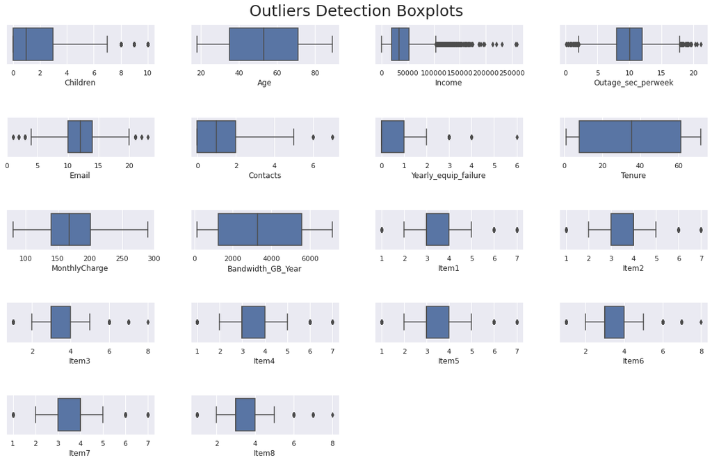

```python
# Function to detect the outliers
def find_outliers(df):
  num_cols =  df.select_dtypes(include = np.number)
  plt.figure(figsize=(17,11))
  plt.xticks()

  for i,col in enumerate(num_cols,1):
    plt.subplot(5,4,i)
    sns.boxplot(df[col])
    # plt.ylabel(col)
    plt.suptitle(' Outliers Detection Boxplots ', fontsize=25)
    plt.tight_layout(pad=4)

  plt.show()

find_outliers(cleaned_churn)
```

```python
# Selecting only the numerical variables
numerical_vars = churn_cl.select_dtypes(include = np.number).columns
numerical_vars
```

```
Index(['Children', 'Age', 'Income', 'Outage_sec_perweek', 'Email', 'Contacts',
       'Yearly_equip_failure', 'Tenure', 'MonthlyCharge', 'Bandwidth_GB_Year',
       'Item1', 'Item2', 'Item3', 'Item4', 'Item5', 'Item6', 'Item7', 'Item8'],
      dtype='object')
```

### Checking for Missing Values

```python
# Find for missing values
cleaned_churn.isna().sum()
```

```
Children                0
Age                     0
Income                  0
Gender                  0
Outage_sec_perweek      0
Email                   0
Contacts                0
Yearly_equip_failure    0
Techie                  0
Contract                0
Port_modem              0
Tablet                  0
InternetService         0
Phone                   0
Multiple                0
OnlineSecurity          0
OnlineBackup            0
DeviceProtection        0
TechSupport             0
StreamingTV             0
StreamingMovies         0
PaperlessBilling        0
Tenure                  0
MonthlyCharge           0
Bandwidth_GB_Year       0
Item1                   0
Item2                   0
Item3                   0
Item4                   0
Item5                   0
Item6                   0
Item7                   0
Item8                   0
Churn                   0
dtype: int64
```

## **Part III: Data Preparation**

**C1: DATA GOALS:**

C. Summarize the data preparation process for multiple regression analysis by doing the following:

Describe your data preparation goals and the data manipulations that will be used to achieve the goals.

The first step I need to take for the data preparation part is to get the data itself; but in my case the Churn dataset is already cleaned and ready for the next step in the lifecycle of the data analysis. Following the data acquisition, I will import Python's data science libraries to my jupyter notebook and then load the dataset using Pandas's csv method. The next step is going to be the data exploration phase where I will be using the tools imported to manipulate the dataset. For example, I will check the size ,shape, distributions, and missing values of my dataset. To manipulate the data, I will use both graphical and tabular techniques to discover patterns in the data. For example, using matplotlib I can create a histogram of each variable to find data distributions. In using a tabular method, I will use stastical summaries to explore the central tendencies of the data for each variable.

Since the goal of this project is to determine the linear relationship between the target and predictor variables, knowing the data distributions makes the decision of choosing appropriate variables less complicated. By manipulating data through visualization and tabular methods, the relationships among the variables can be understood based on the research question and selected accordingly.

Another step is to for check the data types available in the dataset . These include string, numeric, object, and NaN. This is an important step because the multiple linear regression model only deals with numerical data types. By taking into account how many of each data type is in the dataset, appropriate data conversion methods can be used to change non-numerical data types to numerical data types.

**C2: SUMMARY STATISTICS:**

To come up with summary statistics, I will use two approaches;

- a tabular summary statistics -and detailed discussions about the statistics shown in the table.

The summary statistics for the variables are shown below.

```python
# Displaying the statistical summaries of the numerical variables
cleaned_churn.describe()
```

|  | Children | Age | Income | Outage_sec_perweek | Email | Contacts | Yearly_equip_failure | Tenure | MonthlyCharge | Bandwidth_GB_Year | Item1 | Item2 | Item3 | Item4 | Item5 | Item6 | Item7 | Item8 |
| --- | --- | --- | --- | --- | --- | --- | --- | --- | --- | --- | --- | --- | --- | --- | --- | --- | --- | --- |
| count | 10000.0000 | 10000.000000 | 10000.000000 | 10000.000000 | 10000.000000 | 10000.000000 | 10000.000000 | 10000.000000 | 10000.000000 | 10000.000000 | 10000.000000 | 10000.000000 | 10000.000000 | 10000.000000 | 10000.000000 | 10000.000000 | 10000.000000 | 10000.000000 |
| mean | 2.0877 | 53.078400 | 39806.926771 | 10.001848 | 12.016000 | 0.994200 | 0.398000 | 34.526188 | 172.624816 | 3392.341550 | 3.490800 | 3.505100 | 3.487000 | 3.497500 | 3.492900 | 3.497300 | 3.509500 | 3.495600 |
| std | 2.1472 | 20.698882 | 28199.916702 | 2.976019 | 3.025898 | 0.988466 | 0.635953 | 26.443063 | 42.943094 | 2185.294852 | 1.037797 | 1.034641 | 1.027977 | 1.025816 | 1.024819 | 1.033586 | 1.028502 | 1.028633 |
| min | 0.0000 | 18.000000 | 348.670000 | 0.099747 | 1.000000 | 0.000000 | 0.000000 | 1.000259 | 79.978860 | 155.506715 | 1.000000 | 1.000000 | 1.000000 | 1.000000 | 1.000000 | 1.000000 | 1.000000 | 1.000000 |
| 25% | 0.0000 | 35.000000 | 19224.717500 | 8.018214 | 10.000000 | 0.000000 | 0.000000 | 7.917694 | 139.979239 | 1236.470827 | 3.000000 | 3.000000 | 3.000000 | 3.000000 | 3.000000 | 3.000000 | 3.000000 | 3.000000 |
| 50% | 1.0000 | 53.000000 | 33170.605000 | 10.018560 | 12.000000 | 1.000000 | 0.000000 | 35.430507 | 167.484700 | 3279.536903 | 3.000000 | 4.000000 | 3.000000 | 3.000000 | 3.000000 | 3.000000 | 4.000000 | 3.000000 |
| 75% | 3.0000 | 71.000000 | 53246.170000 | 11.969485 | 14.000000 | 2.000000 | 1.000000 | 61.479795 | 200.734725 | 5586.141370 | 4.000000 | 4.000000 | 4.000000 | 4.000000 | 4.000000 | 4.000000 | 4.000000 | 4.000000 |
| max | 10.0000 | 89.000000 | 258900.700000 | 21.207230 | 23.000000 | 7.000000 | 6.000000 | 71.999280 | 290.160419 | 7158.981530 | 7.000000 | 7.000000 | 8.000000 | 7.000000 | 7.000000 | 8.000000 | 7.000000 | 8.000000 |

## Correlations among the variables

```python
# Checking the correlations among the variables
cleaned_churn.corr()
```

|  | Children | Age | Income | Outage_sec_perweek | Email | Contacts | Yearly_equip_failure | Tenure | MonthlyCharge | Bandwidth_GB_Year | Item1 | Item2 | Item3 | Item4 | Item5 | Item6 | Item7 | Item8 |
| --- | --- | --- | --- | --- | --- | --- | --- | --- | --- | --- | --- | --- | --- | --- | --- | --- | --- | --- |
| Children | 1.000000 | -0.029732 | 0.009942 | 0.001889 | 0.004479 | -0.020776 | 0.007321 | -0.005091 | -0.009781 | 0.025585 | 0.011470 | 0.013146 | 0.003394 | -0.016768 | -0.000240 | -0.000547 | 0.000687 | -0.005236 |
| Age | -0.029732 | 1.000000 | -0.004091 | -0.008047 | 0.001588 | 0.015068 | 0.008577 | 0.016979 | 0.010729 | -0.014724 | -0.005972 | 0.006659 | -0.003778 | 0.012237 | -0.008305 | 0.010635 | 0.005353 | 0.015193 |
| Income | 0.009942 | -0.004091 | 1.000000 | -0.010011 | -0.009267 | 0.001233 | 0.005423 | 0.002114 | -0.003014 | 0.003674 | -0.004009 | 0.007718 | -0.002707 | -0.022750 | 0.011111 | 0.001768 | 0.016599 | 0.000740 |
| Outage_sec_perweek | 0.001889 | -0.008047 | -0.010011 | 1.000000 | 0.003994 | 0.015092 | 0.002909 | 0.002932 | 0.020496 | 0.004176 | -0.023338 | -0.008076 | -0.021366 | -0.005992 | -0.004156 | -0.014752 | -0.020854 | 0.008126 |
| Email | 0.004479 | 0.001588 | -0.009267 | 0.003994 | 1.000000 | 0.003040 | -0.016354 | -0.014468 | 0.001997 | -0.014579 | 0.003709 | 0.001156 | 0.012928 | 0.000915 | -0.007929 | 0.014468 | 0.010010 | -0.005857 |
| Contacts | -0.020776 | 0.015068 | 0.001233 | 0.015092 | 0.003040 | 1.000000 | -0.006032 | 0.002820 | 0.004259 | 0.003299 | -0.007364 | -0.003003 | -0.021924 | 0.001071 | 0.004698 | -0.000994 | 0.004579 | -0.012615 |
| Yearly_equip_failure | 0.007321 | 0.008577 | 0.005423 | 0.002909 | -0.016354 | -0.006032 | 1.000000 | 0.012435 | -0.007172 | 0.012034 | 0.007518 | -0.009773 | -0.009372 | -0.006906 | 0.003416 | -0.003995 | -0.010368 | -0.009859 |
| Tenure | -0.005091 | 0.016979 | 0.002114 | 0.002932 | -0.014468 | 0.002820 | 0.012435 | 1.000000 | -0.003337 | 0.991495 | -0.006246 | 0.003073 | 0.002351 | -0.006714 | 0.024618 | -0.010127 | 0.000410 | -0.016347 |
| MonthlyCharge | -0.009781 | 0.010729 | -0.003014 | 0.020496 | 0.001997 | 0.004259 | -0.007172 | -0.003337 | 1.000000 | 0.060406 | 0.009756 | 0.003442 | -0.008487 | -0.000440 | -0.005562 | 0.002943 | -0.006399 | 0.002204 |
| Bandwidth_GB_Year | 0.025585 | -0.014724 | 0.003674 | 0.004176 | -0.014579 | 0.003299 | 0.012034 | 0.991495 | 0.060406 | 1.000000 | -0.007314 | 0.003062 | 0.000978 | -0.007789 | 0.025112 | -0.010352 | -0.001077 | -0.015018 |
| Item1 | 0.011470 | -0.005972 | -0.004009 | -0.023338 | 0.003709 | -0.007364 | 0.007518 | -0.006246 | 0.009756 | -0.007314 | 1.000000 | 0.663069 | 0.578013 | -0.005048 | -0.002553 | 0.402804 | 0.336782 | 0.292728 |
| Item2 | 0.013146 | 0.006659 | 0.007718 | -0.008076 | 0.001156 | -0.003003 | -0.009773 | 0.003073 | 0.003442 | 0.003062 | 0.663069 | 1.000000 | 0.520194 | -0.002438 | 0.001260 | 0.363247 | 0.300324 | 0.254259 |
| Item3 | 0.003394 | -0.003778 | -0.002707 | -0.021366 | 0.012928 | -0.021924 | -0.009372 | 0.002351 | -0.008487 | 0.000978 | 0.578013 | 0.520194 | 1.000000 | -0.009278 | -0.003363 | 0.316845 | 0.264833 | 0.215210 |
| Item4 | -0.016768 | 0.012237 | -0.022750 | -0.005992 | 0.000915 | 0.001071 | -0.006906 | -0.006714 | -0.000440 | -0.007789 | -0.005048 | -0.002438 | -0.009278 | 1.000000 | -0.438100 | 0.235995 | 0.195767 | 0.155759 |
| Item5 | -0.000240 | -0.008305 | 0.011111 | -0.004156 | -0.007929 | 0.004698 | 0.003416 | 0.024618 | -0.005562 | 0.025112 | -0.002553 | 0.001260 | -0.003363 | -0.438100 | 1.000000 | -0.304796 | -0.264566 | -0.185646 |
| Item6 | -0.000547 | 0.010635 | 0.001768 | -0.014752 | 0.014468 | -0.000994 | -0.003995 | -0.010127 | 0.002943 | -0.010352 | 0.402804 | 0.363247 | 0.316845 | 0.235995 | -0.304796 | 1.000000 | 0.380103 | 0.308105 |
| Item7 | 0.000687 | 0.005353 | 0.016599 | -0.020854 | 0.010010 | 0.004579 | -0.010368 | 0.000410 | -0.006399 | -0.001077 | 0.336782 | 0.300324 | 0.264833 | 0.195767 | -0.264566 | 0.380103 | 1.000000 | 0.251541 |
| Item8 | -0.005236 | 0.015193 | 0.000740 | 0.008126 | -0.005857 | -0.012615 | -0.009859 | -0.016347 | 0.002204 | -0.015018 | 0.292728 | 0.254259 | 0.215210 | 0.155759 | -0.185646 | 0.308105 | 0.251541 | 1.000000 |

### Discusion About Summary Statistics

**C3: STEPS TO PREPARE THE DATA:**

Explain the steps used to prepare the data for the analysis, including the annotated code.

- Import the necessary libraries from Python
- Load the dataset
- Perform exploratory data analyses on the dataset
- Looking for the missing values
- Convert the categorical variables into numerical variables by using Pandas's dummy variables' method
- Visualize the variables to check for data distributions and correlations
- Use statistical methods to remove some variables for better prediction
- Build the regression model in original and reduced states
- Test the models _ Explain the models' predicted results through visualizations and discussions
- Evaluate and provide recommendations based on the final model's results

## *Creating Dummy Variables*

Using the code below, the categorical variables in the dataset will be converted into the numerical variables because it's difficult to establish relationships among the variables if they are not all numerical. The method that will be used is the pandas's get_dummies() method. This method converts the values in the categorical variables to either 1 or 0. In linear regression, it's important to avoid multicollinearity that gets introduced when using the dummy variables and therefore any values of the variables that go beyond 1 will be discarded as shown by this formula: k-1 where k represents levels present in the categorical variable. For example in the Gender column, the levels are represent as 'Male' or 'Female'. So k is 2 and therefore the dummy variable is going to be 2 - 1 and that means we only need one variable to be included to linear regression equation.

In the following steps below, code will be generated to create the intended dummy variables.

```python
#Find all categorical variables and then convert to a list
cat_columns = cleaned_churn.select_dtypes(['object']).columns
cat_columns =  list(cat_columns)
cat_columns
```

```
['Gender',
 'Techie',
 'Contract',
 'Port_modem',
 'Tablet',
 'InternetService',
 'Phone',
 'Multiple',
 'OnlineSecurity',
 'OnlineBackup',
 'DeviceProtection',
 'TechSupport',
 'StreamingTV',
 'StreamingMovies',
 'PaperlessBilling',
 'Churn']
```

```python
# This function removes redundancies and creates dummy variables while also removing original categorical variables
def dummified(df, cat_columns):
  for x in cat_columns:
    dummies = pd.get_dummies(df[x], prefix=x, dummy_na=False, drop_first=True)
    df = df.drop(x, 1)
    df = pd.concat([df, dummies], axis=1)
  return df
cleaned_churn = dummified(cleaned_churn, cat_columns)
cleaned_churn.head()
```

|  | Children | Age | Income | Outage_sec_perweek | Email | Contacts | Yearly_equip_failure | Tenure | MonthlyCharge | Bandwidth_GB_Year | Item1 | Item2 | Item3 | Item4 | Item5 | Item6 | Item7 | Item8 | Gender_Male | Gender_Nonbinary | Techie_Yes | Contract_One year | Contract_Two Year | Port_modem_Yes | Tablet_Yes | InternetService_Fiber Optic | InternetService_None | Phone_Yes | Multiple_Yes | … |
| --- | --- | --- | --- | --- | --- | --- | --- | --- | --- | --- | --- | --- | --- | --- | --- | --- | --- | --- | --- | --- | --- | --- | --- | --- | --- | --- | --- | --- | --- | --- |
| 0 | 0 | 68 | 28561.99 | 7.978323 | 10 | 0 | 1 | 6.795513 | 172.455519 | 904.536110 | 5 | 5 | 5 | 3 | 4 | 4 | 3 | 4 | 1 | 0 | 0 | 1 | 0 | 1 | 1 | 1 | 0 | 1 | 0 | … |
| 1 | 1 | 27 | 21704.77 | 11.699080 | 12 | 0 | 1 | 1.156681 | 242.632554 | 800.982766 | 3 | 4 | 3 | 3 | 4 | 3 | 4 | 4 | 0 | 0 | 1 | 0 | 0 | 0 | 1 | 1 | 0 | 1 | 1 | … |
| 2 | 4 | 50 | 9609.57 | 10.752800 | 9 | 0 | 1 | 15.754144 | 159.947583 | 2054.706961 | 4 | 4 | 2 | 4 | 4 | 3 | 3 | 3 | 0 | 0 | 1 | 0 | 1 | 1 | 0 | 0 | 0 | 1 | 1 | … |
| 3 | 1 | 48 | 18925.23 | 14.913540 | 15 | 2 | 0 | 17.087227 | 119.956840 | 2164.579412 | 4 | 4 | 4 | 2 | 5 | 4 | 3 | 3 | 1 | 0 | 1 | 0 | 1 | 0 | 0 | 0 | 0 | 1 | 0 | … |
| 4 | 0 | 83 | 40074.19 | 8.147417 | 16 | 2 | 1 | 1.670972 | 149.948316 | 271.493436 | 4 | 4 | 4 | 3 | 4 | 4 | 4 | 5 | 1 | 0 | 0 | 0 | 0 | 1 | 0 | 1 | 0 | 0 | 0 | … |

```python
# Cleaning up columns names
cleaned_churn.columns = cleaned_churn.columns.str.replace('_Yes','')
```

```python
cleaned_churn.head()
```

|  | Children | Age | Income | Outage_sec_perweek | Email | Contacts | Yearly_equip_failure | Tenure | MonthlyCharge | Bandwidth_GB_Year | Item1 | Item2 | Item3 | Item4 | Item5 | Item6 | Item7 | Item8 | Gender_Male | Gender_Nonbinary | Techie | Contract_One year | Contract_Two Year | Port_modem | Tablet | InternetService_Fiber Optic | InternetService_None | Phone | Multiple | … |
| --- | --- | --- | --- | --- | --- | --- | --- | --- | --- | --- | --- | --- | --- | --- | --- | --- | --- | --- | --- | --- | --- | --- | --- | --- | --- | --- | --- | --- | --- | --- |
| 0 | 0 | 68 | 28561.99 | 7.978323 | 10 | 0 | 1 | 6.795513 | 172.455519 | 904.536110 | 5 | 5 | 5 | 3 | 4 | 4 | 3 | 4 | 1 | 0 | 0 | 1 | 0 | 1 | 1 | 1 | 0 | 1 | 0 | … |
| 1 | 1 | 27 | 21704.77 | 11.699080 | 12 | 0 | 1 | 1.156681 | 242.632554 | 800.982766 | 3 | 4 | 3 | 3 | 4 | 3 | 4 | 4 | 0 | 0 | 1 | 0 | 0 | 0 | 1 | 1 | 0 | 1 | 1 | … |
| 2 | 4 | 50 | 9609.57 | 10.752800 | 9 | 0 | 1 | 15.754144 | 159.947583 | 2054.706961 | 4 | 4 | 2 | 4 | 4 | 3 | 3 | 3 | 0 | 0 | 1 | 0 | 1 | 1 | 0 | 0 | 0 | 1 | 1 | … |
| 3 | 1 | 48 | 18925.23 | 14.913540 | 15 | 2 | 0 | 17.087227 | 119.956840 | 2164.579412 | 4 | 4 | 4 | 2 | 5 | 4 | 3 | 3 | 1 | 0 | 1 | 0 | 1 | 0 | 0 | 0 | 0 | 1 | 0 | … |
| 4 | 0 | 83 | 40074.19 | 8.147417 | 16 | 2 | 1 | 1.670972 | 149.948316 | 271.493436 | 4 | 4 | 4 | 3 | 4 | 4 | 4 | 5 | 1 | 0 | 0 | 0 | 0 | 1 | 0 | 1 | 0 | 0 | 0 | … |

```python
cleaned_churn.shape
```

```
(10000, 37)
```

## **C4: VISUALIZATIONS:**

Exploratory data analysis is performed through a graphical method to learn more about the variables and their relationships. The most important visualizations are the graphs that depict the relationships among the predictor variables so that highly correlated predictor variables can be detected visually. In the following steps, both univariate and bivariate graphical methods will be employed to check variables' correlations.

**Univariate Analysis**

For univariate analysis, each variable is plotted individually to see the data distribution. In this step, data patterns like normal and skewed distributions can be found when graphing the variables one by one.

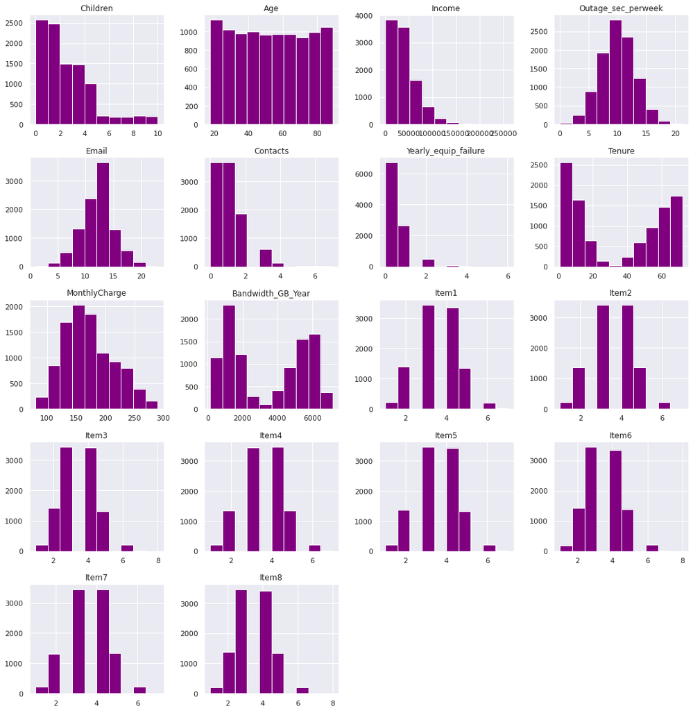

```python
# Univariate graphs
churn_cl.hist(figsize=(18,19), color = 'purple')
plt.show()
```

```python
cat_cols = churn_cl.select_dtypes(['object']).columns
cat_cols =  list(cat_cols)
cat_cols
```

```
['Gender',
 'Techie',
 'Contract',
 'Port_modem',
 'Tablet',
 'InternetService',
 'Phone',
 'Multiple',
 'OnlineSecurity',
 'OnlineBackup',
 'DeviceProtection',
 'TechSupport',
 'StreamingTV',
 'StreamingMovies',
 'PaperlessBilling',
 'Churn']
```

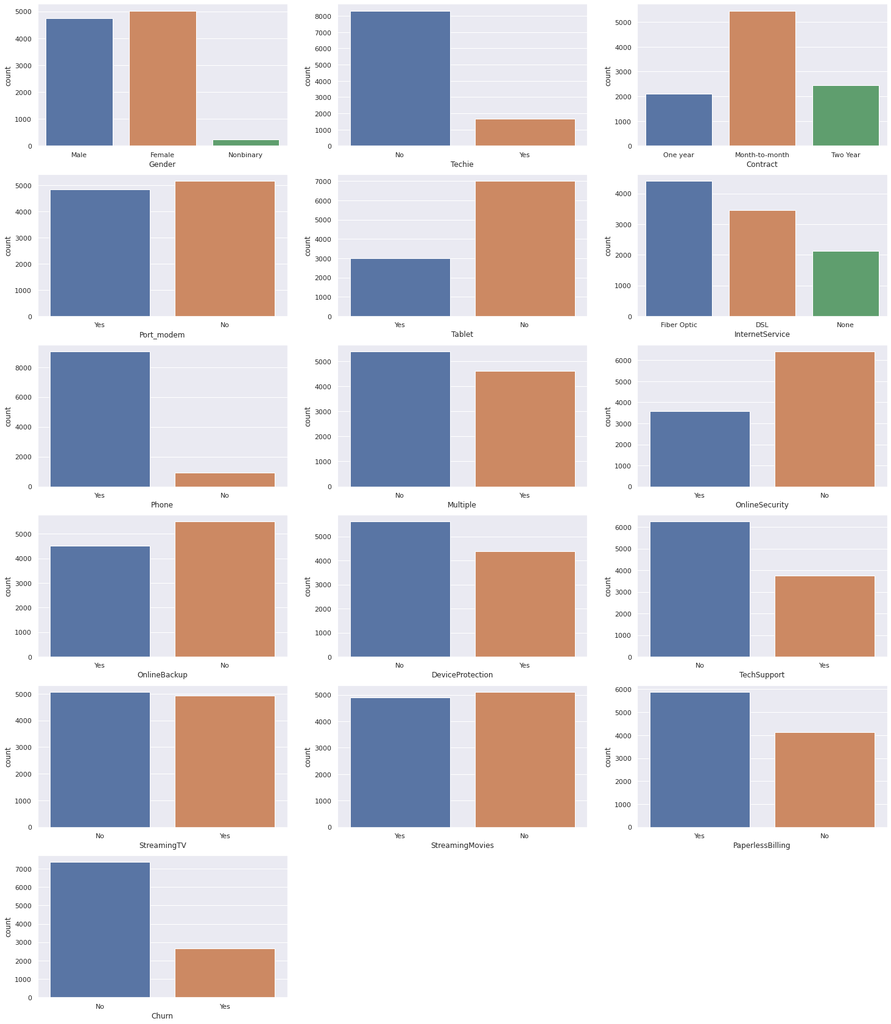

```python
plt.figure(figsize=(25,30))
for i in list(enumerate(cat_cols)):
  plt.subplot(6,3,i[0] + 1)
  sns.countplot(i[1],data=churn_cl)
  plt.xticks(rotation=0)
```

**Bivariate Analysis**

For bivariate analysis, the relationship between two variables are depicted. In this case, the relationship between the predictor and target variables is visualized.

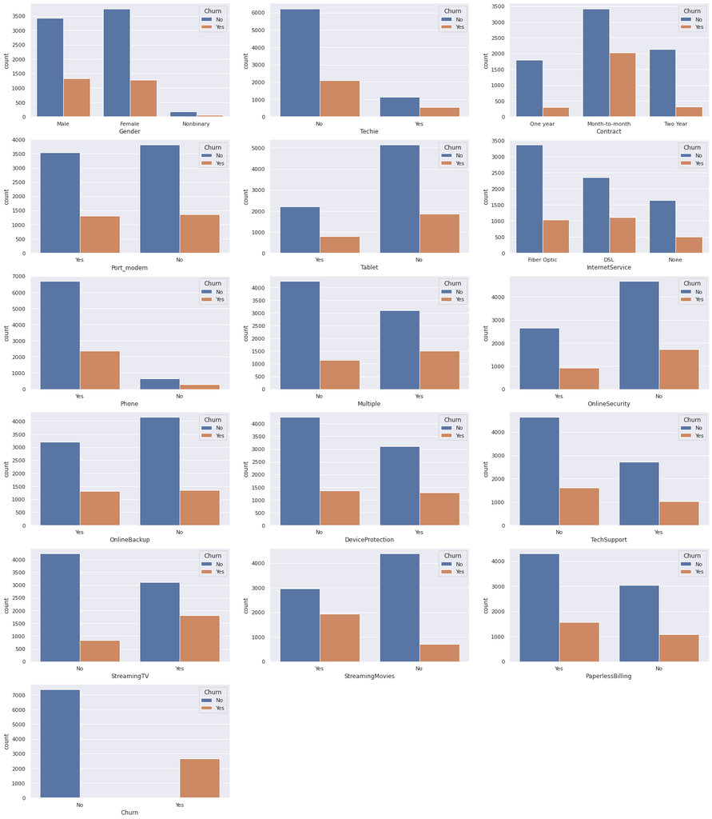

```python
#Bivariate Data Distribution
plt.figure(figsize=(25,30))
for i in list(enumerate(cat_cols)):
  plt.subplot(6,3,i[0] + 1)
  sns.countplot(i[1], hue='Churn', data=churn_cl)
  plt.xticks(rotation=0)
```

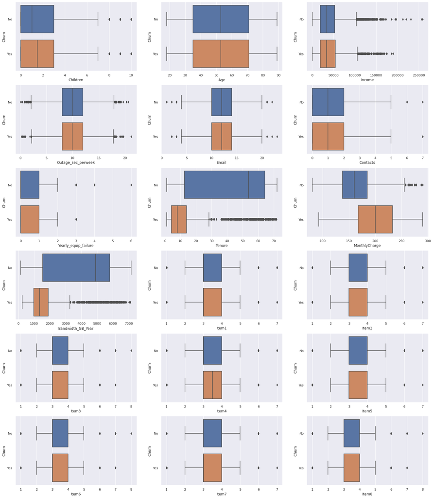

```python
# Boxplots to show relationship among the predictor and target variables
plt.figure(figsize=(25,30))
for i in list(enumerate(numerical_vars)):
  plt.subplot(6,3,i[0] + 1)
  sns.boxplot(i[1],'Churn',data=churn_cl)
  plt.xticks(rotation=0)
```

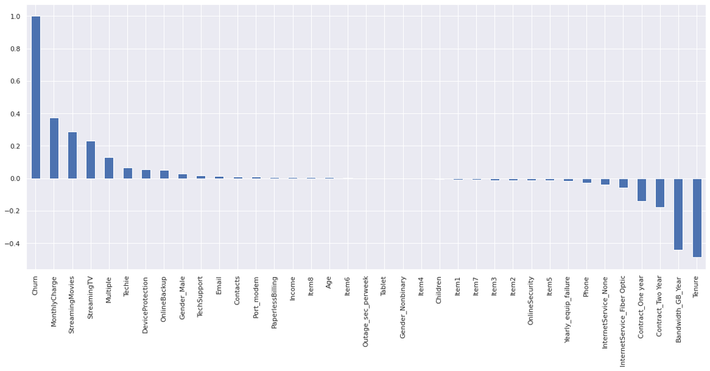

```python
plt.figure(figsize=(20,8))
cleaned_churn.corr()['Churn'].sort_values(ascending = False).plot(kind='bar')
```

## Validating No Multicollinearity Exists

Building a robust model that can be used for business decision-making purposes requires extensive mitigation techniques to tackle some underlying model's problems that don't show up during the model building processes but only later when the model is in the production environment and therefore wreak havoc in providing bad business insights and possibly contribute to customer attrition. To avoid such disasters, two approaches will be employed to make the model a reliable one: using a correlation heatmap and a variance inflation factor (VIF) method to counter multicollinearity problems.

- Variance inflation factor (VIF) is the determination of how much variance of a coefficient is increased due to multicollinearity (Ott et al., 2016) and VIF ranges from 1 indicating no multicollinearity to 5 or 10 indicating multicollinearity. The formula below shows how VIF is calculated for each predictor variable.

  VIF$_{k}$ = 1 / ( 1 - R$^{2}$$_{k}$ )

where **VIF$_{k}$** is VIF for variable *k*, and **R$^{2}$$_{k}$** is the coefficient of determination for the variable *k*.

By plotting the correlation matrix below, one of the assumptions about the logistic regression is validating that no or little multicollinearity among the predictor variables.

There are could be some predictor variables that have some multicollinearity and therefore must be removed. By discarding the variables with multicollinearity, we get one step closer in meeting one of the assumptions of logistic regression.

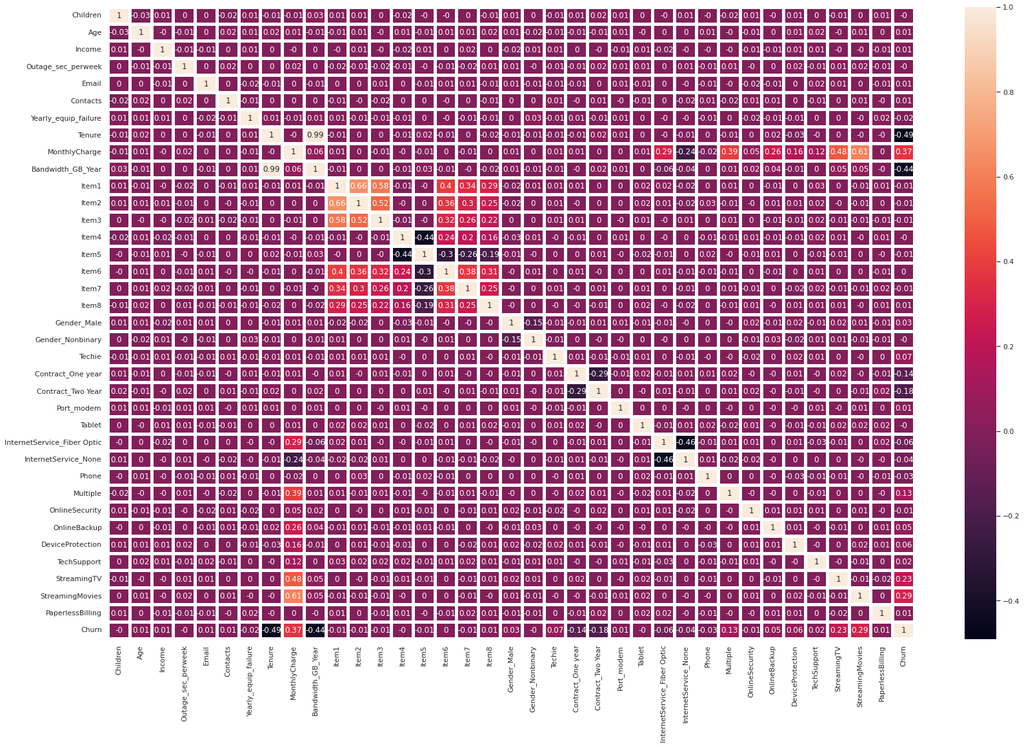

```python
fig,ax = plt.subplots(figsize=(28,18))
sns.heatmap(round(cleaned_churn.corr(),2),annot=True,lw=4, ax=ax)
plt.show()
```

```python
# **Source: https://etav.github.io/python/vif_factor_python.html**

import statsmodels.api as sm
from statsmodels.stats.outliers_influence import variance_inflation_factor
# Function to check Variance Inflation Factor
def check_VIF(df):
  df = cleaned_churn.drop(columns=['Churn'])
  vif = pd.DataFrame()
  vif["features"] = df.columns
  vif["VIF Factor"] = [variance_inflation_factor(df.values, i) for i in range(df.shape[1])]

  return vif.round(1)

check_VIF(cleaned_churn)
```

|  | features | VIF Factor |
| --- | --- | --- |
| 0 | Children | 19.3 |
| 1 | Age | 69.2 |
| 2 | Income | 3.0 |
| 3 | Outage_sec_perweek | 12.2 |
| 4 | Email | 16.7 |
| 5 | Contacts | 2.0 |
| 6 | Yearly_equip_failure | 1.4 |
| 7 | Tenure | 24901.8 |
| 8 | MonthlyCharge | 1436.7 |
| 9 | Bandwidth_GB_Year | 31881.9 |
| 10 | Item1 | 27.3 |
| 11 | Item2 | 24.1 |
| 12 | Item3 | 20.1 |
| 13 | Item4 | 15.9 |
| 14 | Item5 | 16.9 |
| 15 | Item6 | 18.4 |
| 16 | Item7 | 16.6 |
| 17 | Item8 | 14.9 |
| 18 | Gender_Male | 6.3 |
| 19 | Gender_Nonbinary | 1.1 |
| 20 | Techie | 1.2 |
| 21 | Contract_One year | 1.4 |
| 22 | Contract_Two Year | 1.5 |
| 23 | Port_modem | 1.9 |
| 24 | Tablet | 1.4 |
| 25 | InternetService_Fiber Optic | 216.9 |
| 26 | InternetService_None | 53.8 |
| 27 | Phone | 10.7 |
| 28 | Multiple | 10.1 |
| 29 | OnlineSecurity | 4.7 |
| 30 | OnlineBackup | 3.8 |
| 31 | DeviceProtection | 3.3 |
| 32 | TechSupport | 3.9 |
| 33 | StreamingTV | 11.3 |
| 34 | StreamingMovies | 13.1 |
| 35 | PaperlessBilling | 2.4 |

```python
# Checking how columns exceeding the VIF threshold of 5
len([i for i in check_VIF(cleaned_churn.columns)['VIF Factor'] if i > 5])
```

```
22
```

```python
high_collinear_cols = ['Children', 'Age', 'Outage_sec_perweek','Email','MonthlyCharge','Bandwidth_GB_Year','Item1','Item2','Item3','Item4','Item5','Item6','Item7',
'Item8','Gender_Male','InternetService_Fiber Optic','InternetService_None','Phone', 'Multiple','StreamingTV','StreamingMovies']
```

```python
len(high_collinear_cols)
```

```
21
```

#### Dropping Multicollinear Variables

The next step before building the models, the selected variables will be discarded from the dataset and save the refined data for the model building step.

```python
# Drop correlated predictor variables
cleaned_churn = cleaned_churn.drop(columns=high_collinear_cols)
```

```python
# Cbecking for multicollinearity and dropping more predictor variables
check_VIF(cleaned_churn)
```

|  | features | VIF Factor |
| --- | --- | --- |
| 0 | Income | 2.5 |
| 1 | Contacts | 1.9 |
| 2 | Yearly_equip_failure | 1.4 |
| 3 | Tenure | 2.4 |
| 4 | Gender_Nonbinary | 1.0 |
| 5 | Techie | 1.2 |
| 6 | Contract_One year | 1.3 |
| 7 | Contract_Two Year | 1.4 |
| 8 | Port_modem | 1.8 |
| 9 | Tablet | 1.4 |
| 10 | OnlineSecurity | 1.5 |
| 11 | OnlineBackup | 1.7 |
| 12 | DeviceProtection | 1.7 |
| 13 | TechSupport | 1.5 |
| 14 | PaperlessBilling | 2.2 |

## **C5: PREPARED DATA SET:**

```python
data_cleaned = cleaned_churn.to_csv()
```

```python
# Save the dataset to this location below
from pathlib import Path
filepath = Path('/content/drive/MyDrive/Colab Notebooks/Churn_data_cleaned.csv')
filepath.parent.mkdir(parents=True, exist_ok=True)
cleaned_churn.to_csv(filepath)
```

## **Part IV: Model Comparison and Analysis**

**D1: INITIAL MODEL:**

D. Compare an initial and a reduced multiple regression model by doing the following:

The initial model contains all the variables except the ones that don't make any sense to include them such as zipcodes and others. Also some variables are further reduced using correlation matrix, VIF and domain-knowledge methods.

**Churn = -0.0002 + 0.000006Income - 0.000189Contacts - 0.000145Yearly_equip_failure - 0.0110.050309Tenure - 0.000003Gender_Nonbinary + 0.000189Techie - 0.000541Contract_One year - 0.000699Contract_Two Year - 0.000052Port_modem - 0.000104Tablet - 0.000168OnlineSecurity + 0.000167OnlineBackup + 0.000072DeviceProtection+ 0.000021TechSupport - 0.000101PaperlessBilling**

```python
# Building the model
from sklearn.model_selection import train_test_split
from sklearn.linear_model import LogisticRegression
from sklearn.preprocessing import StandardScaler
from sklearn import metrics


# import dmba
# from dmba import classificationSummary, gainsChart, liftChart
# from dmba.metric import AIC_score

X = cleaned_churn.drop(columns='Churn')
Y = cleaned_churn['Churn']
X_train, X_test, y_train, y_test = train_test_split(X, Y, test_size=0.4, random_state=101)

# Setup the model
model = LogisticRegression(penalty="l2", C=1e42, solver='liblinear').fit(X_train,y_train)
print("The number of rows and columns for training data is:",X_train.shape)
print("The number of rows and columns for test data is:",X_test.shape)
print("The number of rows for training data is:",y_train.shape)
print("The number of rows for test data is:",y_test.shape)

# print the intercept
print("The Model's Intercept is :",model.intercept_[0].round(5))
# print('intercept ', logit_reg.intercept_[0])
print(pd.DataFrame({'coeff': model.coef_[0]}, index=X.columns).transpose())
# print('AIC', metrics.roc_auc_score(y_test, model.predict(X_test), df = len(X_train.columns) + 1))
```

```
The number of rows and columns for training data is: (6000, 15)
The number of rows and columns for test data is: (4000, 15)
The number of rows for training data is: (6000,)
The number of rows for test data is: (4000,)
The Model's Intercept is : -0.0002
         Income  Contacts  Yearly_equip_failure    Tenure  Gender_Nonbinary  \
coeff  0.000006 -0.000189             -0.000145 -0.050309         -0.000003

         Techie  Contract_One year  Contract_Two Year  Port_modem    Tablet  \
coeff  0.000189          -0.000541          -0.000699   -0.000052 -0.000104

       OnlineSecurity  OnlineBackup  DeviceProtection  TechSupport  \
coeff       -0.000168      0.000167          0.000072     0.000021

       PaperlessBilling
coeff         -0.000101
```

```python
# Churn = 0.000006Income - 0.000189Contacts - 0.000145Yearly_equip_failure - 0.0110.050309Tenure - 0.000003Gender_Nonbinary
# + 0.000189Techie - 0.000541Contract_One year	- 0.000699Contract_Two Year - 0.000052Port_modem
# - 0.000104Tablet - 0.000168OnlineSecurity + 0.000167OnlineBackup + 0.000072DeviceProtection
# + 0.000021TechSupport - 0.000101PaperlessBilling
```

```python
# The coefficients of the predictor variables shown
coeff_param = pd.DataFrame(model.coef_[0], X.columns,columns=['Coefficient'])
coeff_param
```

|  | Coefficient |
| --- | --- |
| Income | 0.000006 |
| Contacts | -0.000189 |
| Yearly_equip_failure | -0.000145 |
| Tenure | -0.050309 |
| Gender_Nonbinary | -0.000003 |
| Techie | 0.000189 |
| Contract_One year | -0.000541 |
| Contract_Two Year | -0.000699 |
| Port_modem | -0.000052 |
| Tablet | -0.000104 |
| OnlineSecurity | -0.000168 |
| OnlineBackup | 0.000167 |
| DeviceProtection | 0.000072 |
| TechSupport | 0.000021 |
| PaperlessBilling | -0.000101 |

## Predicting the Outcome

```python
# Predicting the outcome
predictions = model.predict(X_test)
predictions
```

```
array([0, 0, 0, ..., 0, 0, 0], dtype=uint8)
```

```python
model.predict_proba(X_test)
```

```
array([[0.95696881, 0.04303119],
       [0.95956765, 0.04043235],
       [0.94247453, 0.05752547],
       ...,
       [0.94290068, 0.05709932],
       [0.5002203 , 0.4997797 ],
       [0.88105258, 0.11894742]])
```

```python
model.score(X_test, y_test)
```

```
0.75425
```

```python
# Displaying the table for actual and predicted values
pred_y_df = pd.DataFrame({'Actual Values': y_test, 'Predicted Values':predictions})
pred_y_df.head(5)
```

|  | Actual Values | Predicted Values |
| --- | --- | --- |
| 6676 | 0 | 0 |
| 6421 | 0 | 0 |
| 9834 | 0 | 0 |
| 8492 | 0 | 0 |
| 9982 | 0 | 0 |

```python
# import the metrics class
from sklearn import metrics

cnf_matrix = metrics.confusion_matrix(y_test,predictions)
cnf_matrix
```

```
array([[2738,  232],
       [ 751,  279]])
```

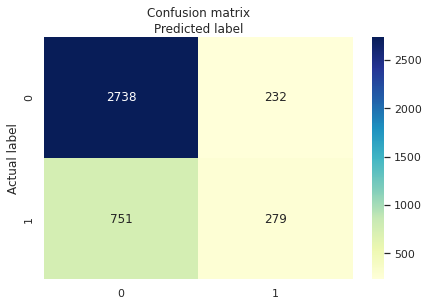

```python
class_names=[0,1] # name  of classes
fig, ax = plt.subplots()
tick_marks = np.arange(len(class_names))
plt.xticks(tick_marks, class_names)
plt.yticks(tick_marks, class_names)
# create heatmap
sns.heatmap(pd.DataFrame(cnf_matrix), annot=True, cmap="YlGnBu" ,fmt='g')
ax.xaxis.set_label_position("top")
plt.tight_layout()
plt.title('Confusion matrix', y=1.1)
plt.ylabel('Actual label')
plt.xlabel('Predicted label')

# Text(0.5,257.44,'Predicted label');
```

```python
from sklearn.metrics import classification_report
target_names = ['Churned', 'Not_Churned']
print(classification_report(y_test, predictions, target_names=target_names))
```

[output not shown]

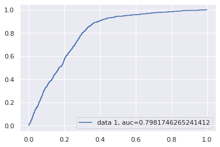

```python
predictions_proba = model.predict_proba(X_test)[::,1]
fpr, tpr, _ = metrics.roc_curve(y_test,  predictions_proba)
auc = metrics.roc_auc_score(y_test, predictions_proba)
plt.plot(fpr,tpr,label="data 1, auc="+str(auc))
plt.legend(loc=4)
plt.show()
```

```python
# lr_model = sm.Logit(Y,X)
# result = lr_model.fit()
lrm = sm.GLM(endog=Y, exog=X, family=sm.families.Binomial())
result = lrm.fit()
```

```python
result.params
```

```
Income                  0.000004
Contacts                0.099861
Yearly_equip_failure    0.024493
Tenure                 -0.059500
Gender_Nonbinary       -0.113043
Techie                  0.603161
Contract_One year      -1.633413
Contract_Two Year      -1.731981
Port_modem              0.213809
Tablet                  0.036405
OnlineSecurity          0.020909
OnlineBackup            0.520393
DeviceProtection        0.404635
TechSupport             0.207942
PaperlessBilling        0.183794
dtype: float64
```

```python
result.summary()
```

Generalized Linear Model Regression Results

| Dep. Variable: | Churn | No. Observations: | 10000 |
| --- | --- | --- | --- |
| Model: | GLM | Df Residuals: | 9985 |
| Model Family: | Binomial | Df Model: | 14 |
| Link Function: | logit | Scale: | 1.0000 |
| Method: | IRLS | Log-Likelihood: | -3912.0 |
| Date: | Mon, 22 Aug 2022 | Deviance: | 7824.0 |
| Time: | 05:07:29 | Pearson chi2: | 8.94e+03 |
| No. Iterations: | 6 |  |  |
| Covariance Type: | nonrobust |  |  |

|  | coef | std err | z | P>\|z\| | [0.025 | 0.975] |
| --- | --- | --- | --- | --- | --- | --- |
| Income | 3.647e-06 | 8.95e-07 | 4.073 | 0.000 | 1.89e-06 | 5.4e-06 |
| Contacts | 0.0999 | 0.027 | 3.686 | 0.000 | 0.047 | 0.153 |
| Yearly_equip_failure | 0.0245 | 0.044 | 0.558 | 0.577 | -0.062 | 0.111 |
| Tenure | -0.0595 | 0.001 | -41.803 | 0.000 | -0.062 | -0.057 |
| Gender_Nonbinary | -0.1130 | 0.184 | -0.615 | 0.538 | -0.473 | 0.247 |
| Techie | 0.6032 | 0.072 | 8.324 | 0.000 | 0.461 | 0.745 |
| Contract_One year | -1.6334 | 0.078 | -21.045 | 0.000 | -1.786 | -1.481 |
| Contract_Two Year | -1.7320 | 0.076 | -22.898 | 0.000 | -1.880 | -1.584 |
| Port_modem | 0.2138 | 0.054 | 3.950 | 0.000 | 0.108 | 0.320 |
| Tablet | 0.0364 | 0.060 | 0.603 | 0.547 | -0.082 | 0.155 |
| OnlineSecurity | 0.0209 | 0.058 | 0.363 | 0.716 | -0.092 | 0.134 |
| OnlineBackup | 0.5204 | 0.055 | 9.438 | 0.000 | 0.412 | 0.628 |
| DeviceProtection | 0.4046 | 0.055 | 7.353 | 0.000 | 0.297 | 0.512 |
| TechSupport | 0.2079 | 0.056 | 3.685 | 0.000 | 0.097 | 0.319 |
| PaperlessBilling | 0.1838 | 0.054 | 3.403 | 0.001 | 0.078 | 0.290 |

**D2: JUSTIFICATION OF MODEL REDUCTION:**

Justify a statistically based variable selection procedure and a model evaluation metric to reduce the initial model in a way that aligns with the research question.

In generalized regression models, there are many methods to reduce the number of predictor variables in the dataset. One of the approaches applied to our dataset is the use of p-value. The p-value method decreases the number of variables to their most statistically significant features so that the model can improve the prediction accuracy and provide better interpretation by using a smaller subset of variables that have strongest effects(Hastie et al., 2017).

By comparing and contrasting the initial and reduced models, the p-values can be determined and the model is further reduced if the p-values are above the threshold of 0.05.

**D3: REDUCED MULTIPLE REGRESSION MODEL:**

Looking at the initial model results, 11 variables have p-values less than 0.05 and therefore they will be used to construct our reduced multiple linear regression model equation.

```python
# Selecting statistically significant variables only
selected_vars = cleaned_churn.drop(columns=['Yearly_equip_failure','Gender_Nonbinary', 'Tablet', 'OnlineSecurity'])
selected_vars
```

|  | Income | Contacts | Tenure | Techie | Contract_One year | Contract_Two Year | Port_modem | OnlineBackup | DeviceProtection | TechSupport | PaperlessBilling | Churn |
| --- | --- | --- | --- | --- | --- | --- | --- | --- | --- | --- | --- | --- |
| 0 | 28561.99 | 0 | 6.795513 | 0 | 1 | 0 | 1 | 1 | 0 | 0 | 1 | 0 |
| 1 | 21704.77 | 0 | 1.156681 | 1 | 0 | 0 | 0 | 0 | 0 | 0 | 1 | 1 |
| 2 | 9609.57 | 0 | 15.754144 | 1 | 0 | 1 | 1 | 0 | 0 | 0 | 1 | 0 |
| 3 | 18925.23 | 2 | 17.087227 | 1 | 0 | 1 | 0 | 0 | 0 | 0 | 1 | 0 |
| 4 | 40074.19 | 2 | 1.670972 | 0 | 0 | 0 | 1 | 0 | 0 | 1 | 0 | 1 |
| ... | ... | ... | ... | ... | ... | ... | ... | ... | ... | ... | ... | ... |
| 9995 | 55723.74 | 2 | 68.197130 | 0 | 0 | 0 | 1 | 1 | 1 | 0 | 0 | 0 |
| 9996 | 34129.34 | 2 | 61.040370 | 0 | 0 | 1 | 0 | 1 | 1 | 0 | 0 | 0 |
| 9997 | 45983.43 | 0 | 47.416890 | 0 | 0 | 0 | 0 | 1 | 0 | 0 | 1 | 0 |
| 9998 | 16667.58 | 1 | 71.095600 | 0 | 0 | 1 | 0 | 0 | 0 | 1 | 1 | 0 |
| 9999 | 9020.92 | 1 | 63.350860 | 0 | 0 | 0 | 1 | 1 | 1 | 0 | 1 | 0 |

10000 rows × 12 columns

```python
# Building the model
from sklearn.linear_model import LogisticRegression
from sklearn.model_selection import train_test_split
X = selected_vars.drop(columns='Churn')
Y = selected_vars['Churn']
X_train, X_test, y_train, y_test = train_test_split(X, Y, test_size=0.4, random_state=101)
# Check the rows and columns
print("Rows and Columns of Training Data:", X_train.shape)
print("Rows and Columns of Test Data:",X_test.shape)
print(y_train.shape)
print(y_test.shape)

# Model setup
model = LogisticRegression()
model.fit(X_train,y_train)

# print the intercept
print("The model's intercept is:", model.intercept_.round(5))
```

```
Rows and Columns of Training Data: (6000, 11)
Rows and Columns of Test Data: (4000, 11)
(6000,)
(4000,)
The model's intercept is: [-0.00042]
```

```python
model.coef_[0]
```

```
array([ 6.21483909e-06, -4.25697460e-04, -5.16159038e-02,  1.42646116e-05,
       -2.46166445e-04, -3.24296183e-04, -2.01082720e-04, -1.15148820e-04,
       -1.15813440e-04, -1.18437515e-04, -2.50980963e-04])
```

```python
# Coeffiecient of the predictor variables shown
coeff_parameter = pd.DataFrame(model.coef_[0],X.columns,columns=['Coefficient'])
coeff_parameter.round(5)
```

|  | Coefficient |
| --- | --- |
| Income | 0.00001 |
| Contacts | -0.00043 |
| Tenure | -0.05162 |
| Techie | 0.00001 |
| Contract_One year | -0.00025 |
| Contract_Two Year | -0.00032 |
| Port_modem | -0.00020 |
| OnlineBackup | -0.00012 |
| DeviceProtection | -0.00012 |
| TechSupport | -0.00012 |
| PaperlessBilling | -0.00025 |

```python
# Predicting the outcome
predictions = model.predict(X_test)
predictions
```

```
array([0, 0, 0, ..., 0, 1, 0], dtype=uint8)
```

```python
model.predict_proba(X_test)
```

```
array([[0.95960816, 0.04039184],
       [0.96223072, 0.03776928],
       [0.94605147, 0.05394853],
       ...,
       [0.94619037, 0.05380963],
       [0.49791773, 0.50208227],
       [0.88330709, 0.11669291]])
```

```python
# Model Accuracy
model.score(X_test, y_test)
```

```
0.7565
```

```python
# import the metrics class
from sklearn import metrics

cnf_matrix = metrics.confusion_matrix(y_test,predictions)
cnf_matrix
```

```
array([[2730,  240],
       [ 734,  296]])
```

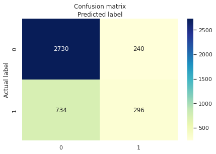

```python
class_names=[0,1] # name  of classes
fig, ax = plt.subplots()
tick_marks = np.arange(len(class_names))
plt.xticks(tick_marks, class_names)
plt.yticks(tick_marks, class_names)
# create heatmap
sns.heatmap(pd.DataFrame(cnf_matrix), annot=True, cmap="YlGnBu" ,fmt='g')
ax.xaxis.set_label_position("top")
plt.tight_layout()
plt.title('Confusion matrix', y=1.1)
plt.ylabel('Actual label')
plt.xlabel('Predicted label')
```

```python
from sklearn.metrics import classification_report
target_names = ['Churned', 'Not_Churned']
print(classification_report(y_test, predictions, target_names=target_names))
```

[output not shown]

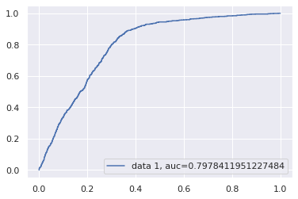

```python
predictions_proba = model.predict_proba(X_test)[::,1]
fpr, tpr, _ = metrics.roc_curve(y_test,  predictions_proba)
auc = metrics.roc_auc_score(y_test, predictions_proba)
plt.plot(fpr,tpr,label="data 1, auc="+str(auc))
plt.legend(loc=4)
plt.show()
```

E. Analyze the data set using your reduced multiple regression model by doing the following:

**E1: MODEL COMPARISON:**

The initial multiple regression model contains 15 variables compared to the reduced regression with 11 variables in which the p-value and VIF techniques were used to remove the correlated predictor variables .

After running both the initial and the reduced models one after anothoer, a evaluation metric called confusion matrix is used. The confusion matrix evaluates the accuracy of the model by creating a tabular actual vs predicted values to help find the percentage of churners and non-churners(2020). To the accuracies of both models are 0.75 and 0.76, respectively. The accuracy of the reduced model improved after removing some variables in the initial model.

**E2: OUTPUT AND CALCULATIONS:**

Check parts D1 and D2 for output and calculations

**E3: CODE:**

Check parts D1 and D2.

## **Part V: Data Summary and Implications**

F. Summarize your findings and assumptions by doing the following:

**F1: RESULTS:**

Discuss the results of your data analysis, including the following elements:

### Regression Equation for the Reduced Model

Here's the equation representing the reduced regression model:

Churn = -0.0004 + 0.00001Income - 0.0004Contacts - 0.05Tenure + 0.00001Techie - 0.0003Contract_One year - 0.0003Contract_Two Year - 0.0002Port_modem - 0.00012OnlineBackup - 0.000122DeviceProtection - 0.00012TechSupport - 0.00025PaperlessBilling

### Interpretation of Coefficients of the Statistically Significant Variables of the Model

There are 11 variables that are statistically significant as their p-values are below 0.05: Income, Contacts, Tenure, Techie, Contract_One_year, Contract_Two_year, Port_modem, OnlineBackup,DeviceProtection, TechSupport, and PaperlessBilling. With the exception of Income and Techie variables' coefficients, all the other variables' coefficients are negatively contributing to the target variable, Churn. The positive coefficients indicate that if all variables in the model are equal, customers with levels of income and being techie are more likely to churn than other customers(Gold & Tzuo, 2020).

### The Statistical and Practical Significance of the Model

Since the p-values of the significant variables are below the threshold of 0.05, they are statistically significant because there exists a relationship among the predictor and target variables and therefore it is not by chance they are related.

Because the model's accuracy is 0.76, the model is practically signicant as the variables in the dataset tend to relate to customers' likelihood of churning or not.

### Limitations of the Data Analysis

Even though the model's accuracy is somewhat acceptable when predicting the outcome, churn, it's hard to justify the inclusion or exclusion of some variables as they lack practical application when predicting the target variable (the case of overfitting). For example, some categorical variables create overfitting problems in the application of multiple regression model as they require steps to first convert them into numerical variables which reduces the degree of freedom. The number of degree of freedom signifies the number of predictor variables of information present to predict the target variable and the less the number of predictor variables the less information to build a model that can generalize to other datasets and therefore the result is overfitting problems that limit the model's accuracy on other datasets(Nisbet et al., 2018).

**F2: RECOMMENDATIONS:**

From the equation of the reduced model,income and techie variables have positive coefficients. These would suggest that that customers in these two categories have higher influence in determining the chances of being churned and therefore the company should strive to provide better data plans coupled with improved extra services like data storage, device protection, and conservation of environment by encouraging the customers to use paperless billing. By taking into consideration all these variables, the company can be successful for a very long time.

## **Part VI: Demonstration**

**G: PANOPTO DEMONSTRATION:**

https://wgu.hosted.panopto.com/Panopto/Pages/Viewer.aspx?id=7429c30c-dab8-4842-8f03-aef900496471

**H: SOURCES OF THIRD-PARTY CODE:**

Tavares, E. (n.d.). Variance inflation factor (VIF) explained. Ernest Tavares III Full RSS. Retrieved July 29, 2022, from https://etav.github.io/python/vif_factor_python.html

**I: SOURCES:**

avcontentteam. (2020, June 26). Logistic regression R: Introduction to logistic regression. Analytics Vidhya. Retrieved August 21, 2022, from https://www.analyticsvidhya.com/blog/2015/11/beginners-guide-on-logistic-regression-in-r/

Bobbitt, Z. (2022, June 20). What is explained variance? (definition & example). Statology. Retrieved July 16, 2022, from https://www.statology.org/explained-variance/

Bock, T. (2020, December 2). How to interpret logistic regression coefficients. Displayr. Retrieved August 21, 2022, from https://www.displayr.com/how-to-interpret-logistic-regression-coefficients/

Frankenfield, J. (2021, September 21). Reading into Predictive modeling. Investopedia. Retrieved July 2, 2022, from https://www.investopedia.com/terms/p/predictive-modeling.asp

Gold, C., & Tzuo, T. (2020). Fighting churn with data: The science and strategy of customer retention. Manning Publications Co.

Hastie, T. J., Friedman, J. H., & Tibshirani, R. (2017). Linear Methods for Regression. In The elements of Statistical Learning: Data Mining, Inference, and prediction (pp. 57–57). essay, Springer.

Lantz, B. (2019). Machine learning with r: Expert techniques for Predictive modeling. Packt Publishing.

Nisbet, R., Yale, K., Elder, J. F., Miner, G., & Peterson, A. (2018). Handbook of Statistical Analysis and Data Mining Applications. Elsevier Academic Press.

Ott, L., & Longnecker, M. (2016). Linear Regression and Correlation . In An introduction to statistical methods & data analysis (pp. 555–556). essay, Cengage Learning.

Pardoe, I. (2021). Applied Regression Modeling. Wiley.

Rane, Z. (2021, August 19). 10 compelling reasons to learn Python for data science. Medium. Retrieved July 2, 2022, from https://towardsdatascience.com/10-compelling-reasons-to-learn-python-for-data-science-fa31160321cb

Shmueli, G., Bruce, P. C., Gedeck, P., & Patel, N. R. (2020). Data mining for Business Analytics: Concepts, techniques and applications in Python. Wiley.

Why should you learn Python for data science? 7 Reasons Why You Should Master Python For Data Science. (2022, May 31). Retrieved July 2, 2022, from https://www.andlearning.org/why-should-you-learn-python-for-data-science/